# Image Classification and Recommender System

```python
# compute cosine similarities between images
cosSimilarities = cosine_similarity(imgs_features)
# store the results into a pandas dataframe
cos_similarities_df = pd.DataFrame(cosSimilarities, columns=files, index=files)
cos_similarities_df.head()
```

|  | C:/Users/linli/Desktop/In progress project/WSI/product_file/0.jpg | C:/Users/linli/Desktop/In progress project/WSI/product_file/1.jpg | C:/Users/linli/Desktop/In progress project/WSI/product_file/10.jpg | C:/Users/linli/Desktop/In progress project/WSI/product_file/100.jpg | C:/Users/linli/Desktop/In progress project/WSI/product_file/101.jpg | C:/Users/linli/Desktop/In progress project/WSI/product_file/102.jpg | C:/Users/linli/Desktop/In progress project/WSI/product_file/103.jpg | C:/Users/linli/Desktop/In progress project/WSI/product_file/104.jpg | C:/Users/linli/Desktop/In progress project/WSI/product_file/105.jpg | C:/Users/linli/Desktop/In progress project/WSI/product_file/106.jpg | ... | C:/Users/linli/Desktop/In progress project/WSI/product_file/90.jpg | C:/Users/linli/Desktop/In progress project/WSI/product_file/91.jpg | C:/Users/linli/Desktop/In progress project/WSI/product_file/92.jpg | C:/Users/linli/Desktop/In progress project/WSI/product_file/93.jpg | C:/Users/linli/Desktop/In progress project/WSI/product_file/94.jpg | C:/Users/linli/Desktop/In progress project/WSI/product_file/95.jpg | C:/Users/linli/Desktop/In progress project/WSI/product_file/96.jpg | C:/Users/linli/Desktop/In progress project/WSI/product_file/97.jpg | C:/Users/linli/Desktop/In progress project/WSI/product_file/98.jpg | C:/Users/linli/Desktop/In progress project/WSI/product_file/99.jpg |
| --- | --- | --- | --- | --- | --- | --- | --- | --- | --- | --- | --- | --- | --- | --- | --- | --- | --- | --- | --- | --- | --- |
| C:/Users/linli/Desktop/In progress project/WSI/product_file/0.jpg | 1.000000 | 0.566342 | 0.589725 | 0.304929 | 0.283740 | 0.272410 | 0.363936 | 0.302487 | 0.307303 | 0.312110 | ... | 0.279317 | 0.251743 | 0.238592 | 0.336092 | 0.294794 | 0.481797 | 0.266188 | 0.232489 | 0.333702 | 0.278810 |
| C:/Users/linli/Desktop/In progress project/WSI/product_file/1.jpg | 0.566342 | 1.000000 | 0.486930 | 0.296348 | 0.279526 | 0.276505 | 0.397123 | 0.260545 | 0.249207 | 0.270370 | ... | 0.324476 | 0.362456 | 0.236665 | 0.324902 | 0.259335 | 0.356800 | 0.283941 | 0.253952 | 0.292422 | 0.282447 |
| C:/Users/linli/Desktop/In progress project/WSI/product_file/10.jpg | 0.589725 | 0.486930 | 1.000000 | 0.319486 | 0.336696 | 0.345366 | 0.464929 | 0.342896 | 0.252080 | 0.282110 | ... | 0.305154 | 0.328901 | 0.308729 | 0.342598 | 0.312655 | 0.398736 | 0.304422 | 0.284514 | 0.369625 | 0.280276 |
| C:/Users/linli/Desktop/In progress project/WSI/product_file/100.jpg | 0.304929 | 0.296348 | 0.319486 | 1.000000 | 0.776352 | 0.684804 | 0.600392 | 0.671952 | 0.429179 | 0.501297 | ... | 0.573602 | 0.657322 | 0.552224 | 0.338581 | 0.550519 | 0.319672 | 0.499267 | 0.597011 | 0.577676 | 0.503183 |
| C:/Users/linli/Desktop/In progress project/WSI/product_file/101.jpg | 0.283740 | 0.279526 | 0.336696 | 0.776352 | 1.000000 | 0.861654 | 0.622486 | 0.717644 | 0.490436 | 0.491441 | ... | 0.585652 | 0.705248 | 0.546135 | 0.381792 | 0.623394 | 0.355076 | 0.499025 | 0.640361 | 0.621840 | 0.495688 |

5 rows × 609 columns

```python
# function to retrieve the most similar products for a given one

def image_based_recommendations(given_img):

    print("-----------------------------------------------------------------------")
    print("original product:")
    original = load_img(given_img, target_size=(imgs_model_width, imgs_model_height))
    fig = plt.figure()
    fig.set_size_inches(5,5)
    plt.imshow(original)

    plt.show()

    print("-----------------------------------------------------------------------")
    print("most similar products:")

    closest_imgs = cos_similarities_df[given_img].sort_values(ascending=False)[1:nb_closest_images+1].index
    closest_imgs_scores = cos_similarities_df[given_img].sort_values(ascending=False)[1:nb_closest_images+1]

    for i in range(0,len(closest_imgs)):
        original = load_img(closest_imgs[i], target_size=(imgs_model_width, imgs_model_height))
        fig = plt.figure()
        fig.set_size_inches(5,5)
        plt.imshow(original)
        plt.show()
        print("similarity score : ",closest_imgs_scores[i])
```

[output not shown]

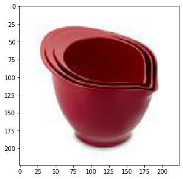

```
-----------------------------------------------------------------------
most similar products:
```

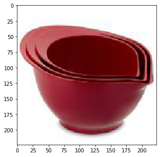

```
similarity score :  0.8836961
```

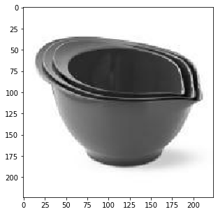

```
similarity score :  0.6794099
```

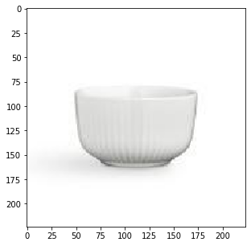

```
similarity score :  0.5835591
```

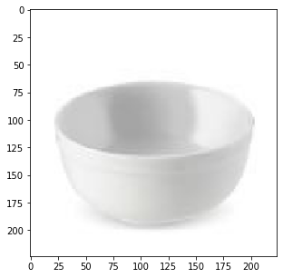

```
similarity score :  0.5663423
```

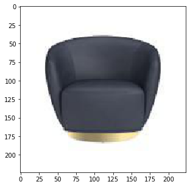

```
similarity score :  0.5550671
```

```python
image_based_recommendations(files[1])
```

[output not shown]

[figure not shown]

```
-----------------------------------------------------------------------
most similar products:
```

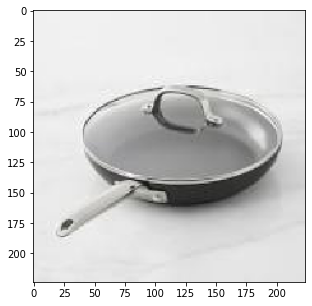

```
similarity score :  0.96511716
```

[figure not shown]

```
similarity score :  0.83996004
```

[figure not shown]

```
similarity score :  0.8389548
```

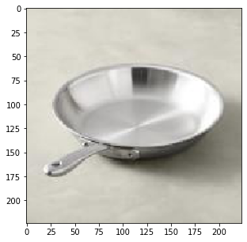

```
similarity score :  0.8268065
```

[figure not shown]

```
similarity score :  0.81590164
```

```python
image_based_recommendations(files[100])
```

[output not shown]

### B: Text-based recommender system

**Idea:** if instead given the product title, then calculate similarity scores for the title and find the most similar product titles in my database.  
**Method explained:**  
• Data preprocessing: when dealing with text data, we need to convert the text data to numbers that way computer can understand. I convert the word vector of each title then compute Term Frequency-Inverse Document Frequency (TF-IDF) vectors for each title.  
What is Term Frequency-Inverse Document Frequency (TF-IDF)?  
Term Frequency: a measure of the frequency of the word in the current document.  
Inverse Document Frequency: a measure of how rare the word is across documents, which tells us how significant the term is among the documents.  
The higher value of the term, the rarer it is in the document.  
• Calculation of cosine similarity between the product titles: since we have used the TF-IDF vectorizer, calculating the dot product will directly give us the cosine similarity score. Therefore, we will use sklearn's linear_kernel() instead of cosine_similarities() since it is faster.  
• Build the title-based recommender system: a function is created that takes in the product title and returns the top 10 recommendations. The similarity score is arranged in descending order, and results are given based on the score.

```python
data['title'].sample(5)
```

```
570    Williams Sonoma Silicone Spoonula with Stainle...
489                                         Windsor Sofa
144    Nespresso Lattissima Touch by De'Longhi Espres...
96               Cuisinart Coffee On Demand Coffee Maker
411                                Braided Flatweave Rug
Name: title, dtype: object
```

```python
#Import TfIdfVectorizer from scikit-learn
#from sklearn.feature_extraction.text import TfidfVectorizer

#Define a TF-IDF Vectorizer Object. Remove all english stop words such as 'the', 'a'
tfidf = TfidfVectorizer(stop_words='english')

#Construct the required TF-IDF matrix by fitting and transforming the data
tfidf_matrix = tfidf.fit_transform(data['title'])

#Output the shape of tfidf_matrix
tfidf_matrix.shape
```

```
(609, 732)
```

There are 609 Products and 732 are unique words in the product title.

```python
# Compute the cosine similarity matrix
cosine_sim = linear_kernel(tfidf_matrix, tfidf_matrix)
```

```python
cosine_sim_table=pd.DataFrame(cosine_sim)
cosine_sim_table.columns=data['title']
cosine_sim_table.index=data['title']
cosine_sim_table
```

| title | Williams Sonoma Pantry Cereal/Soup Bowl, Set of 6 | Melamine Mixing Bowls with Spout, Set of 3 | 10-Piece Glass Mixing Bowl Set | Open Kitchen by Williams Sonoma All Purpose Bowls | Flour Shop Melamine Mixing Bowls with Lids, Set of 6 | Reactive Glaze Cereal Bowls | Japanese Garden Large Bowls, Mixed | Palace Garden Mixed Noodle Bowls | Melamine Pour Spout Bowls, Set of 3, Red | Melamine Pour Spout Bowls, Set of 3, Grey | ... | Williams Sonoma Scoop & Spread Tool | Williams Sonoma Open Kitchen Grey Silicone Utensils, Turner | Williams Sonoma Stainless-Steel Slotted Turner/Spatula | HARRY POTTER™ SLYTHERIN™ Ultimate Silicone Spatula Set | Williams Sonoma Signature Stainless Steel Slotted Spatula | Williams Sonoma Signature Nonstick Burger Spatula | Open Kitchen by Williams Sonoma Beechwood Angled Spatula | Open Kitchen by Williams Sonoma All Nylon Turner/Spatula | HARRY POTTER™ RAVENCLAW™ Spatula | Williams Sonoma Flex Core Mini Spatulas, Set of 2, Navy |
| --- | --- | --- | --- | --- | --- | --- | --- | --- | --- | --- | --- | --- | --- | --- | --- | --- | --- | --- | --- | --- | --- |
| Williams Sonoma Pantry Cereal/Soup Bowl, Set of 6 | 1.000000 | 0.050803 | 0.241058 | 0.152100 | 0.040861 | 0.207613 | 0.000000 | 0.000000 | 0.046583 | 0.049020 | ... | 0.138531 | 0.131101 | 0.163751 | 0.043031 | 0.161593 | 0.164337 | 0.133007 | 0.145692 | 0.000000 | 0.180857 |
| Melamine Mixing Bowls with Spout, Set of 3 | 0.050803 | 1.000000 | 0.350303 | 0.144708 | 0.576495 | 0.139976 | 0.126896 | 0.122795 | 0.657234 | 0.691613 | ... | 0.000000 | 0.000000 | 0.000000 | 0.046421 | 0.000000 | 0.000000 | 0.000000 | 0.000000 | 0.000000 | 0.048609 |
| 10-Piece Glass Mixing Bowl Set | 0.241058 | 0.350303 | 1.000000 | 0.000000 | 0.281746 | 0.000000 | 0.000000 | 0.000000 | 0.052077 | 0.054801 | ... | 0.000000 | 0.000000 | 0.000000 | 0.048106 | 0.000000 | 0.000000 | 0.000000 | 0.000000 | 0.000000 | 0.050373 |
| Open Kitchen by Williams Sonoma All Purpose Bowls | 0.152100 | 0.144708 | 0.000000 | 1.000000 | 0.116387 | 0.139054 | 0.126060 | 0.121987 | 0.132688 | 0.139628 | ... | 0.148459 | 0.438514 | 0.175487 | 0.000000 | 0.173174 | 0.176115 | 0.444888 | 0.487317 | 0.000000 | 0.145530 |
| Flour Shop Melamine Mixing Bowls with Lids, Set of 6 | 0.040861 | 0.576495 | 0.281746 | 0.116387 | 1.000000 | 0.112581 | 0.102061 | 0.098763 | 0.319733 | 0.336458 | ... | 0.000000 | 0.000000 | 0.000000 | 0.037336 | 0.000000 | 0.000000 | 0.000000 | 0.000000 | 0.000000 | 0.039096 |
| ... | ... | ... | ... | ... | ... | ... | ... | ... | ... | ... | ... | ... | ... | ... | ... | ... | ... | ... | ... | ... | ... |
| Williams Sonoma Signature Nonstick Burger Spatula | 0.164337 | 0.000000 | 0.000000 | 0.176115 | 0.000000 | 0.000000 | 0.000000 | 0.000000 | 0.000000 | 0.000000 | ... | 0.160404 | 0.151801 | 0.310536 | 0.095772 | 0.528626 | 1.000000 | 0.252233 | 0.276289 | 0.115991 | 0.157239 |
| Open Kitchen by Williams Sonoma Beechwood Angled Spatula | 0.133007 | 0.000000 | 0.000000 | 0.444888 | 0.000000 | 0.000000 | 0.000000 | 0.000000 | 0.000000 | 0.000000 | ... | 0.129823 | 0.383468 | 0.251333 | 0.077513 | 0.248021 | 0.252233 | 1.000000 | 0.513226 | 0.093878 | 0.127262 |
| Open Kitchen by Williams Sonoma All Nylon Turner/Spatula | 0.145692 | 0.000000 | 0.000000 | 0.487317 | 0.000000 | 0.000000 | 0.000000 | 0.000000 | 0.000000 | 0.000000 | ... | 0.142205 | 0.560693 | 0.450985 | 0.084906 | 0.271675 | 0.276289 | 0.513226 | 1.000000 | 0.102831 | 0.139399 |
| HARRY POTTER™ RAVENCLAW™ Spatula | 0.000000 | 0.000000 | 0.000000 | 0.000000 | 0.000000 | 0.000000 | 0.000000 | 0.000000 | 0.000000 | 0.000000 | ... | 0.000000 | 0.000000 | 0.115578 | 0.519728 | 0.114054 | 0.115991 | 0.093878 | 0.102831 | 1.000000 | 0.000000 |
| Williams Sonoma Flex Core Mini Spatulas, Set of 2, Navy | 0.180857 | 0.048609 | 0.050373 | 0.145530 | 0.039096 | 0.000000 | 0.000000 | 0.000000 | 0.044571 | 0.046903 | ... | 0.132547 | 0.125438 | 0.156678 | 0.041172 | 0.154613 | 0.157239 | 0.127262 | 0.139399 | 0.000000 | 1.000000 |

609 rows × 609 columns

The more similar the title, the higher the cosine similarity score.

```python
#Construct a reverse map of indices and product titles
indices = pd.Series(data.index, index=data['title']).drop_duplicates()
```

```python
# Function that takes in a title as input and outputs top 10 most similar product titles
def title_based_recommendations(title, cosine_sim=cosine_sim):
    # Get the index of the product that matches the title
    idx = indices[title]

    # Get the pairwsie similarity scores of all product titles with that title
    sim_scores = list(enumerate(cosine_sim[idx]))

    # Sort the titles based on the similarity scores
    sim_scores = sorted(sim_scores, key=lambda x: x[1], reverse=True)

    # Get the scores of the 10 most similar titles
    sim_scores = sim_scores[1:11]

    # Get the titles indices
    product_indices = [i[0] for i in sim_scores]

    # Return the top 10 most similar titles
    return data['title'].iloc[product_indices]
```

```python
title_based_recommendations('Staub Perfect Pan')
```

```
174                     Staub Enameled Cast Iron Fry Pan
148    Brim 0.8 Liter Precision Temperature & Perfect...
162    Staub Enameled Cast Iron Traditional Deep Skil...
175    Calphalon Elite Nonstick 3-Piece Fry Pan & Sau...
192                  All-Clad d5 Stainless-Steel Fry Pan
201                     Calphalon Elite Nonstick Fry Pan
547                                Littledeer Pan Paddle
205                 SCANPAN Classic Nonstick Fry Pan Set
171                SCANPAN Professional Nonstick Fry Pan
187         All-Clad d5 Stainless-Steel Nonstick Fry Pan
Name: title, dtype: object
```

```python
title_based_recommendations('Robinson Clear Glass Pendant')
```

```
400         Robinson Seeded Glass Pendant
379    Katie Conical Pendant, Clear Glass
354                 Kira Clear Table Lamp
361    Katie Conical Pendant, White Glass
387                         Davis Pendant
344                        Emmett Pendant
363                         Agnes Pendant
381                Garrison Brass Pendant
398        Garrison Antique White Pendant
343               Montego Pendant, Rattan
Name: title, dtype: object
```